# CEE218X_HW5

Chenbo Wang

10/25/2020

```r
library(lehdr)
library(plotly)
library(tidyverse)
library(tigris)
library(sf)
library(leaflet)
library(censusapi)
Sys.setenv(CENSUS_KEY="df5d39697e74ea76fdb9bea9b3a60afd0eeb0b2d")
library(mapboxapi)
mb_access_token("sk.eyJ1Ijoid2FuZ2NiOTgiLCJhIjoiY2tnenJuOW80MDhjaTJycXU5eG90eXVnaCJ9.-CHiWfChZ2aHquv5jXI-NQ", install = T, overwrite=T)
```

```r
#read from local machine
SFBI_data <- read_csv("SFBI Database.csv")
```

```r
# filter to include only ballot drop-off stations in San Mateo
SFBI_SM_ballot <-
  SFBI_data %>% filter(
    `city (from address) (from locations) 3` == "San Mateo"
    ) %>% filter(
      `taxonomy` == "Ballot Drop Off"
      ) %>% mutate(
      latitude = as.numeric(`latitude (from locations) 2`)
      )%>% mutate(
      longtitude = as.numeric(`longitude (from locations) 2`)
      ) %>% select(
        c("Name", "id", "service_options", "weekday (from schedule) 3", "opens_at (from schedule) 3", "closes_at (from schedule) 3","latitude","longtitude")
                   ) %>% st_as_sf(
        coords = c("longtitude","latitude"), crs = 4236)
```

```r
walk_10min <- mb_isochrone(
  SM_county_ballot,
  profile = "walking",
  time = 10
)

SM_county_ballot_walk_10min <-
  SM_county_ballot %>%
  st_set_geometry(NULL) %>%
  cbind(walk_10min$geometry) %>%
  st_as_sf()
```

```r
leaflet() %>%
  addMapboxTiles(
    style_id = "streets-v11",
    username = "mapbox"
  ) %>%
  addPolygons(
    data = SM_county_ballot_walk_10min,
    label = ~Name,
    color = "blue",
    weight = 2
  ) %>%
  addPolygons(
    data = SM_county %>%
      st_transform(4326),
    fill = F,
    weight = 2,
    color = "red"
  )
```

[interactive chart not shown]

The logic behind the choosing of cycling in lieu of walking as pattern is that we hope to increase the size of isochrones to avoid including only a very small number of people, so as to reduce sensitivity to imputation errors and allows for equity analysis on different social groups. In terms of commuting profile, “cycling” instead of “driving” is used because cycling is a more realistic choice for non-drivers, which are more likely to be discouraged from dropping ballot in person. Especially during the ongoing Covid-19 public health crisis, non-drivers may prefer biking over other transportation means such as taking a taxi or riding a bus.

Compared to previous 10-min-walking isochrones, the 15-min-cycling isochrones are much largers, thereby covering a reasonable part of San Mateo county. Henceforth, the analysis of accessibility to ballot drop-off locations will be based on these 15-min-cycling isochrones.

```r
#profile= which can be “driving”, “driving-traffic”, “cycling”, or “walking”.
cycling_15min <- mb_isochrone(
  SM_county_ballot,
  profile = "cycling",
  time = 15
)

SM_county_ballot_cycling_15min <-
  SM_county_ballot %>%
  st_set_geometry(NULL) %>%
  cbind(cycling_15min$geometry) %>%
  st_as_sf()

leaflet() %>%
  addMapboxTiles(
    style_id = "streets-v11",
    username = "mapbox"
  ) %>%
  addPolygons(
    data = SM_county_ballot_cycling_15min,
    label = ~Name,
    weight = 1
  ) %>%
  addPolygons(
    data = SM_county %>%
      st_transform(4326),
    fill = F,
    weight = 2,
    color = "red"
  )
```

[interactive chart not shown]

Use 2017 LODES information about residents (RAC) or workers (WAC) at the block group or block level; if you would like to use other ACS characteristics in your analysis, you can add them as supplemental analyses. Clearly state all assumptions and include an interpretation of your results. Results can include counts of the % of a target population in a County that has what you define “good access” to the services, and/or an equity analysis comparing the full population to the “service-accessible” population along some group identity of interest.

```r
#ca_rac <- grab_lodes(
#  state = "CA",
#  year = 2017,
#  lodes_type = "rac",
#  job_type = "JT01",
#  state_part = "main",
#  agg_geo = "bg"
#)
# saveRDS(ca_rac,"ca_rac.rds")
ca_rac <- readRDS("ca_rac.rds")
```

```r
SM_bgs <-block_groups("06", county = "081", year = 2017) %>%
  filter(TRACTCE != "990100")%>%
  st_transform(26910) %>%
  mutate(original_area = st_area(.))
```

```r
SM_rac <-
  ca_rac %>%
  filter(h_bg %in% SM_bgs$GEOID) %>%
  left_join(
    SM_bgs,
    by = c("h_bg" = "GEOID")
  ) %>%
  st_as_sf()
```

```r
SM_bg_isochrone_intersect <-
  SM_bgs %>%
  st_intersection(
    SM_county_ballot_cycling_15min %>%
      st_union() %>%
      st_transform(26910)
  ) %>%
  mutate(
    leftover_area = st_area(.),
    perc_area = leftover_area / original_area
  )
```

```r
SM_rac_ballot <- SM_rac %>%
  left_join(
    SM_bg_isochrone_intersect %>%
      select(h_bg = GEOID, perc_area) %>%
      st_set_geometry(NULL)
  )
```

A quick review of the documentation for data structure reveals that varaibles CD01 ~ CD04 respectively represent number of jobs for workers with **Educational Attainment**: Less than high school; High school or equivalent,no college; Some college or Associate degree; Bachelor’s degree or advanced degree.

Because we have already tidied the data such that for each block groups the population in each educational attainment levels are estimated as: **the total number of persons in each educational attainment levels times the percentage of areas covered by these 15-min-cycling isochrones.** It is noteworthy that such methodology is essentially assuming a homogeneous distribution of different social groups (people of different socioeconomic status), i.e., population is randomly uniformly distributed. Such assumption could potentially limit the accuracy of our analysis in that filtering (where people of lower socioeconmics got filtered to poorer neighborhood with older buildings) does exist and that population is not uniformly distributed in space. Another factor that could potentially harm the usefulness of this analysis is that data on Educational Attainment is only available for workers of age 30 and older.

Other than Educational Attainment, socioeconomic status of interest typically include Income Level, as financial conditions usually dominates in many situations. For example, higher-income people have better access to private cars and could choose where they live (potentially close to ballot drop-off locations). The variable code CE01 to CE03 represent respectively number of jobs for workers with **Income Level**: jobs with earnings $1250/month or less; $1251/month to $3333/month; and greater than $3333/month.

Age also matters in that older people may find it necessary to have a ballot drop-off location close to where they live. The variable code CA01 to CA03 represent respectively number of jobs for workers with **Age Category**: age 29 or younger; age 30 to 54; and age 55 or older. The goal here is to sort of performs an equity analysis to see whether the accessibility to ballot drop off stations is differential between different social groups, the **race** is also of concern. CR01, CR02, CR03, CR04, CR05, CR07 respectively represent: number of jobs for workers with Race: White Alone; Black or African American Alone; American Indian or Alaska Native Alone; Asian Alone; Native Hawaiian or Other Pacific Islander Alone; Two or More Race Groups.

```r
SM_rac_ballot_education <- SM_rac_ballot %>%
  filter(!is.na(perc_area)) %>%
  mutate(
    education1 = CD01 * perc_area
  ) %>%
  mutate(
    education2 = CD02 * perc_area
  ) %>%
  mutate(
    education3 = CD03 * perc_area
  ) %>%
  mutate(
    education4 = CD04 * perc_area
  )
```

```r
SM_rac_ballot_income <- SM_rac_ballot %>%
  filter(!is.na(perc_area)) %>%
  mutate(
    income1 = CE01 * perc_area
  ) %>%
  mutate(
    income2 = CE02 * perc_area
  ) %>%
  mutate(
    income3 = CE03 * perc_area
  )
```

```r
SM_rac_ballot_age <- SM_rac_ballot %>%
  filter(!is.na(perc_area)) %>%
  mutate(
    age1 = CA01 * perc_area
  ) %>%
  mutate(
    age2 = CA02 * perc_area
  ) %>%
  mutate(
    age3 = CA03 * perc_area
  )
```

```r
SM_rac_ballot_race <- SM_rac_ballot %>%
  filter(!is.na(perc_area)) %>%
  mutate(
    race1 = CR01 * perc_area
  ) %>%
  mutate(
    race2 = CR02 * perc_area
  ) %>%
  mutate(
    race3 = CR03 * perc_area
  ) %>%
  mutate(
    race4 = CR04 * perc_area
  ) %>%
  mutate(
    race5 = CR05 * perc_area
  ) %>%
  mutate(
    race7 = CR07 * perc_area
  )
```

```r
edu_ballot <- rep(0,4)
edu_ballot[1] <- sum(SM_rac_ballot_education$education1)
edu_ballot[2] <- sum(SM_rac_ballot_education$education2)
edu_ballot[3] <- sum(SM_rac_ballot_education$education3)
edu_ballot[4] <- sum(SM_rac_ballot_education$education4)
(edu_isochrone_total <- sum(edu_ballot))
```

```
## [1] 67044.04
```

```r
edu_total <- rep(0,4)
edu_total[1] <- sum(SM_rac$CD01)
edu_total[2] <- sum(SM_rac$CD02)
edu_total[3] <- sum(SM_rac$CD03)
edu_total[4] <- sum(SM_rac$CD04)
(total_jobs_edu <- sum(edu_total))
```

```
## [1] 280039
```

```r
edu_isochrone_total/total_jobs_edu
```

```
## [1] 0.2394096
```

```r
educational_level <- c(
  "Less than high school",
  "High school or equivalent,no college",
  "Some college or Associate degree",
  "Bachelor's degree or advanced degree"
)

education_results <- cbind(edu_ballot,edu_total) %>%
  as.data.frame() %>%
  mutate(total_perc = edu_total/total_jobs_edu) %>%
  mutate(ballot_perc = edu_ballot/edu_isochrone_total) %>%
  cbind(educational_level)
```

```r
income_ballot <- rep(0,3)
income_ballot[1] <- sum(SM_rac_ballot_income$income1)
income_ballot[2] <- sum(SM_rac_ballot_income$income2)
income_ballot[3] <- sum(SM_rac_ballot_income$income3)

income_total <- rep(0,3)
income_total[1] <- sum(SM_rac$CE01)
income_total[2] <- sum(SM_rac$CE02)
income_total[3] <- sum(SM_rac$CE03)

income_level <- c(
  "$1250/month or less", "$1251/month to $3333/month", "greater than $3333/month"
)

income_results <- cbind(income_ballot,income_total) %>%
  as.data.frame() %>%
  mutate(total_perc = income_total/sum(income_total)) %>%
  mutate(ballot_perc = income_ballot/sum(income_ballot)) %>%
  cbind(income_level)
```

```r
age_ballot <- rep(0,3)
age_ballot[1] <- sum(SM_rac_ballot_age$age1)
age_ballot[2] <- sum(SM_rac_ballot_age$age2)
age_ballot[3] <- sum(SM_rac_ballot_age$age3)

age_total <- rep(0,3)
age_total[1] <- sum(SM_rac$CA01)
age_total[2] <- sum(SM_rac$CA02)
age_total[3] <- sum(SM_rac$CA03)

age_category <- c("age 29 or younger", "age 30 to 54", "age 55 or older")

age_results <- cbind(age_ballot,age_total) %>%
  as.data.frame() %>%
  mutate(total_perc = age_total/sum(age_total)) %>%
  mutate(ballot_perc = age_ballot/sum(age_ballot)) %>%
  cbind(age_category)
```

```r
race_ballot <- rep(0,3)
race_ballot[1] <- sum(SM_rac_ballot_race$race1)
race_ballot[2] <- sum(SM_rac_ballot_race$race2)
race_ballot[3] <- sum(SM_rac_ballot_race$race3)
race_ballot[4] <- sum(SM_rac_ballot_race$race4)
race_ballot[5] <- sum(SM_rac_ballot_race$race5)
race_ballot[6] <- sum(SM_rac_ballot_race$race7)


race_total <- rep(0,6)
race_total[1] <- sum(SM_rac$CR01)
race_total[2] <- sum(SM_rac$CR02)
race_total[3] <- sum(SM_rac$CR03)
race_total[4] <- sum(SM_rac$CR04)
race_total[5] <- sum(SM_rac$CR05)
race_total[6] <- sum(SM_rac$CR07)

race_group <- c("White Alone", "Black or African American Alone", "American Indian or Alaska Native Alone", "Asian Alone", "Native Hawaiian or Other Pacific Islander Alone", "Two or More Race Groups")

race_results <- cbind(race_ballot,race_total) %>%
  as.data.frame() %>%
  mutate(total_perc = race_total/sum(race_total)) %>%
  mutate(ballot_perc = race_ballot/sum(race_ballot))  %>%
  cbind(race_group)
```

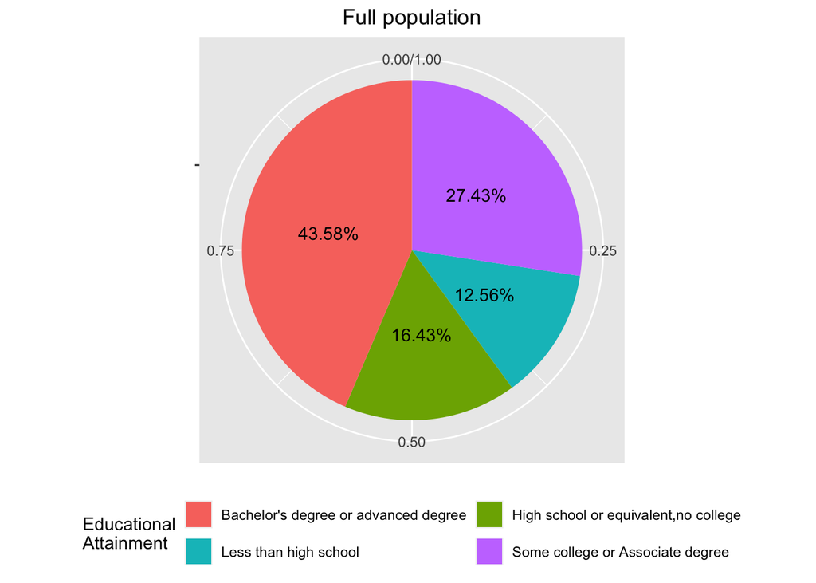

```r
par(mfrow=c(1,2))
education_results %>%
  ggplot(
    aes(
      x = "",
      y = total_perc,
      fill = educational_level
    )
  ) +
  geom_bar(
    stat = "identity",
    position = position_fill()
  ) +
  geom_text(
    aes(label = paste0(round(total_perc*100,2),"%")),
    position = position_fill(vjust = 0.5)
  ) +
  coord_polar(theta = "y") +
  theme(
    axis.title.x = element_blank(),
    axis.title.y = element_blank(),
    legend.position = 'bottom'
  ) +
  guides(
    fill = guide_legend(nrow=2, byrow=TRUE)
  ) +
  labs(
    fill = "Educational\nAttainment"
  ) +
  ggtitle("Full population") +
  theme(plot.title = element_text(hjust = 0.5))
```

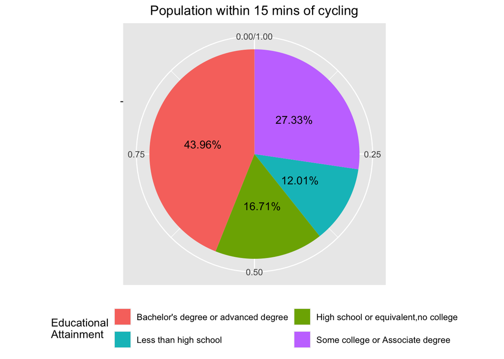

```r
education_results %>%
  ggplot(
    aes(
      x = "",
      y = ballot_perc,
      fill = educational_level
    )
  ) +
  geom_bar(
    stat = "identity",
    position = position_fill()
  ) +
  geom_text(
    aes(label = paste0(round(ballot_perc*100,2),"%")),
    position = position_fill(vjust = 0.5)
  ) +
  coord_polar(theta = "y") +
  theme(
    axis.title.x = element_blank(),
    axis.title.y = element_blank(),
    legend.position = 'bottom'
  ) +
  guides(
    fill = guide_legend(nrow=2, byrow=TRUE)
  ) +
  labs(
    fill = "Educational\nAttainment"
  ) +
  ggtitle("Population within 15 mins of cycling") +
  theme(plot.title = element_text(hjust = 0.5))
```

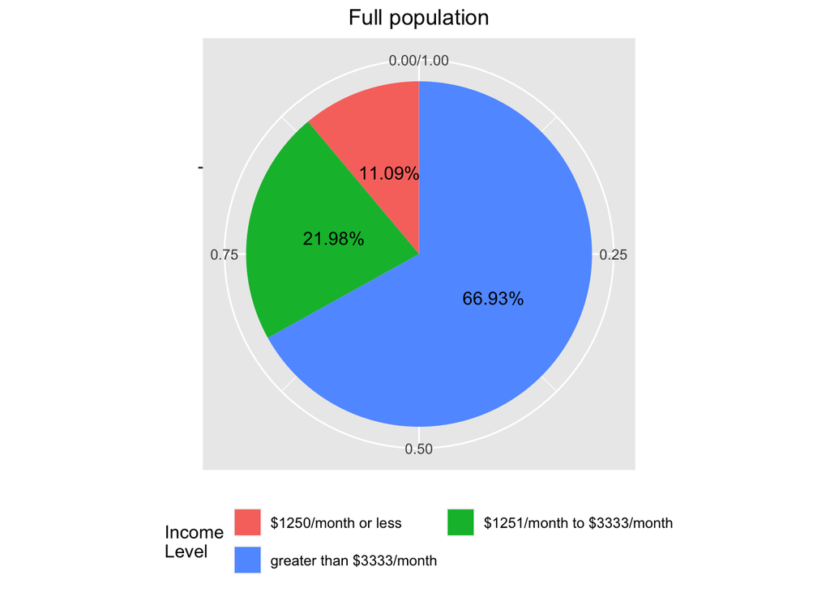

```r
par(mfrow=c(1,2))
income_results %>%
  ggplot(
    aes(
      x = "",
      y = total_perc,
      fill = income_level
    )
  ) +
  geom_bar(
    stat = "identity",
    position = position_fill()
  ) +
  geom_text(
    aes(label = paste0(round(total_perc*100,2),"%")),
    position = position_fill(vjust = 0.5)
  ) +
  coord_polar(theta = "y") +
  theme(
    axis.title.x = element_blank(),
    axis.title.y = element_blank(),
    legend.position = 'bottom'
  ) +
  guides(
    fill = guide_legend(nrow=2, byrow=TRUE)
  ) +
  labs(
    fill = "Income\nLevel"
  ) +
  ggtitle("Full population") +
  theme(plot.title = element_text(hjust = 0.5))
```

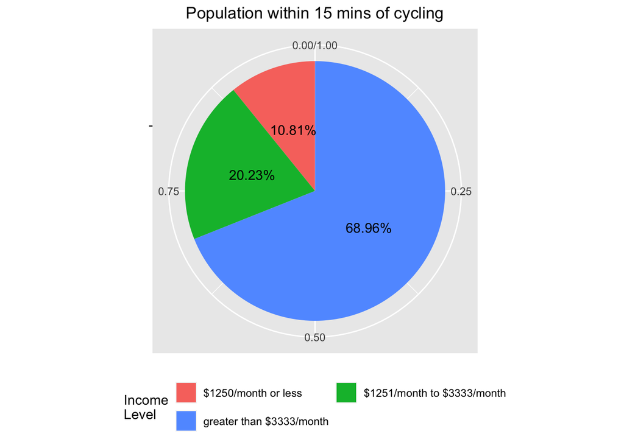

```r
income_results %>%
  ggplot(
    aes(
      x = "",
      y = ballot_perc,
      fill = income_level
    )
  ) +
  geom_bar(
    stat = "identity",
    position = position_fill()
  ) +
  geom_text(
    aes(label = paste0(round(ballot_perc*100,2),"%")),
    position = position_fill(vjust = 0.5)
  ) +
  coord_polar(theta = "y") +
  theme(
    axis.title.x = element_blank(),
    axis.title.y = element_blank(),
    legend.position = 'bottom'
  ) +
  guides(
    fill = guide_legend(nrow=2, byrow=TRUE)
  ) +
  labs(
    fill = "Income\nLevel"
  ) +
  ggtitle("Population within 15 mins of cycling") +
  theme(plot.title = element_text(hjust = 0.5))
```

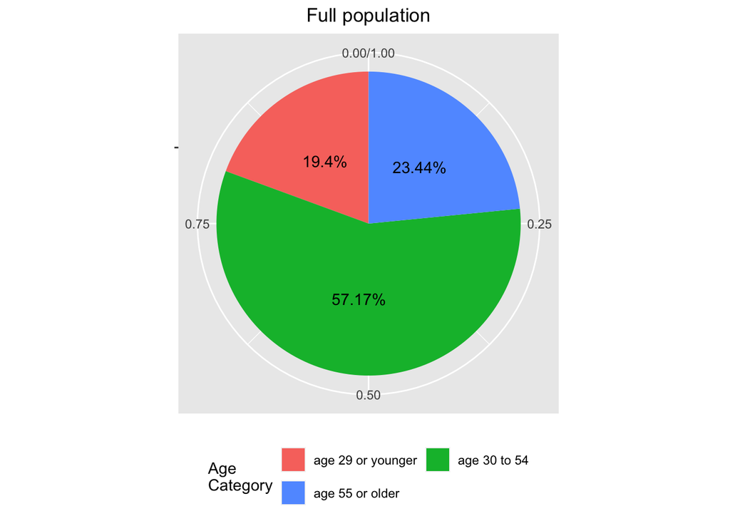

```r
par(mfrow=c(1,2))
age_results %>%
  ggplot(
    aes(
      x = "",
      y = total_perc,
      fill = age_category
    )
  ) +
  geom_bar(
    stat = "identity",
    position = position_fill()
  ) +
  geom_text(
    aes(label = paste0(round(total_perc*100,2),"%")),
    position = position_fill(vjust = 0.5)
  ) +
  coord_polar(theta = "y") +
  theme(
    axis.title.x = element_blank(),
    axis.title.y = element_blank(),
    legend.position = 'bottom'
  ) +
  guides(
    fill = guide_legend(nrow=2, byrow=TRUE)
  ) +
  labs(
    fill = "Age\nCategory"
  ) +
  ggtitle("Full population") +
  theme(plot.title = element_text(hjust = 0.5))
```

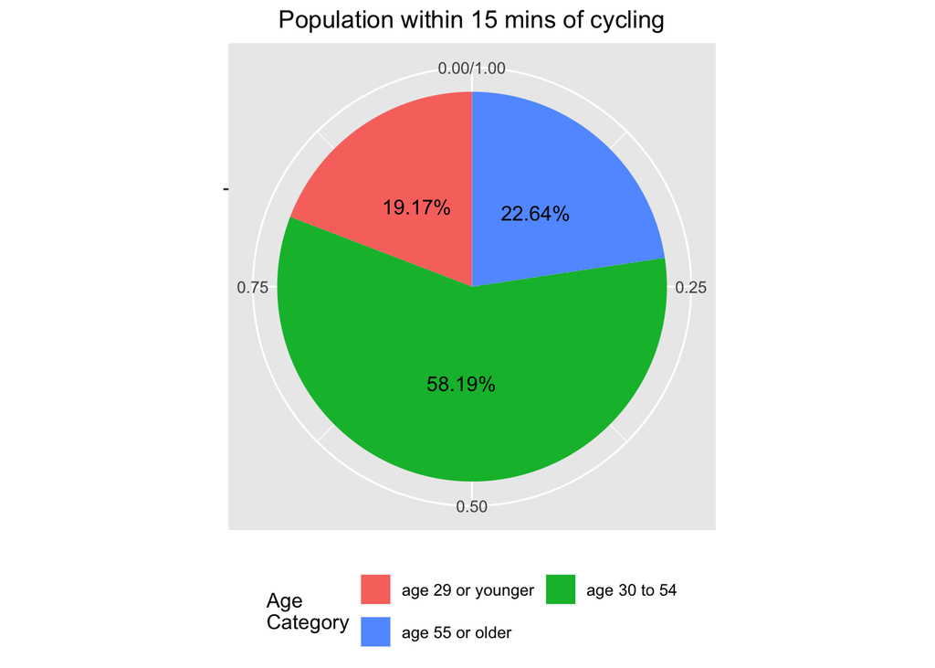

```r
age_results %>%
  ggplot(
    aes(
      x = "",
      y = ballot_perc,
      fill = age_category
    )
  ) +
  geom_bar(
    stat = "identity",
    position = position_fill()
  ) +
  geom_text(
    aes(label = paste0(round(ballot_perc*100,2),"%")),
    position = position_fill(vjust = 0.5)
  ) +
  coord_polar(theta = "y") +
  theme(
    axis.title.x = element_blank(),
    axis.title.y = element_blank(),
    legend.position = 'bottom'
  ) +
  guides(
    fill = guide_legend(nrow=2, byrow=TRUE)
  ) +
  labs(
    fill = "Age\nCategory"
  ) +
  ggtitle("Population within 15 mins of cycling") +
  theme(plot.title = element_text(hjust = 0.5))
```

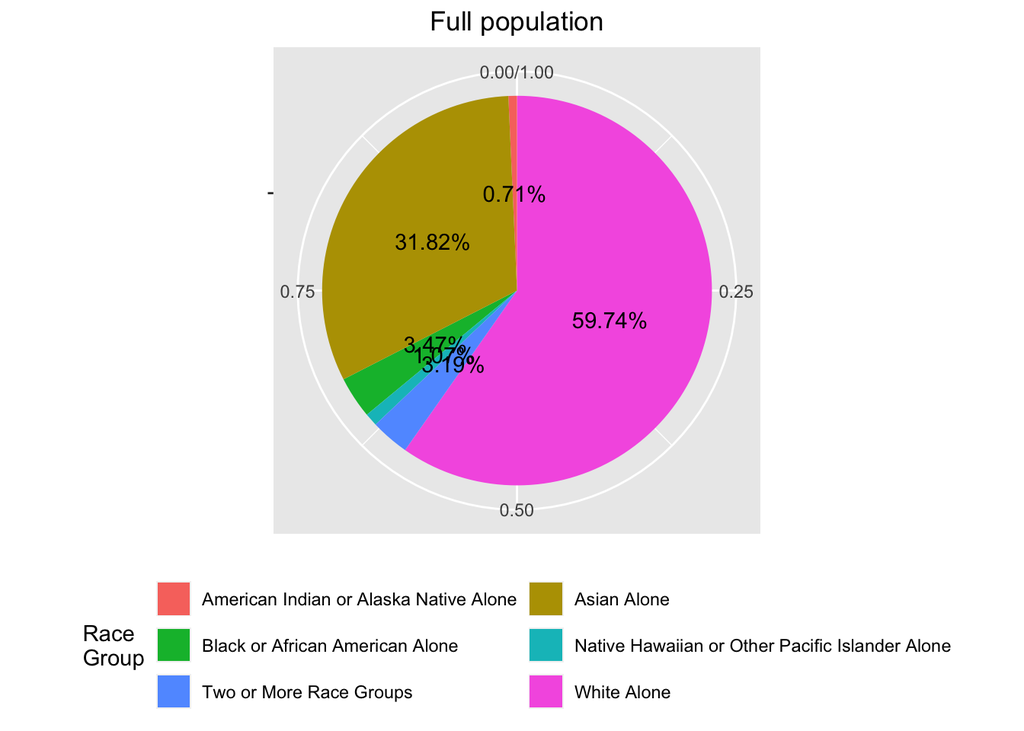

```r
par(mfrow=c(1,2))
race_results %>%
  ggplot(
    aes(
      x = "",
      y = total_perc,
      fill = race_group
    )
  ) +
  geom_bar(
    stat = "identity",
    position = position_fill()
  ) +
  geom_text(
    aes(label = paste0(round(total_perc*100,2),"%")),
    position = position_fill(vjust = 0.5)
  ) +
  coord_polar(theta = "y") +
  theme(
    axis.title.x = element_blank(),
    axis.title.y = element_blank(),
    legend.position = 'bottom'
  ) +
  guides(
    fill = guide_legend(nrow=3, byrow=TRUE)
  ) +
  labs(
    fill = "Race\nGroup"
  ) +
  ggtitle("Full population") +
  theme(plot.title = element_text(hjust = 0.5))
```

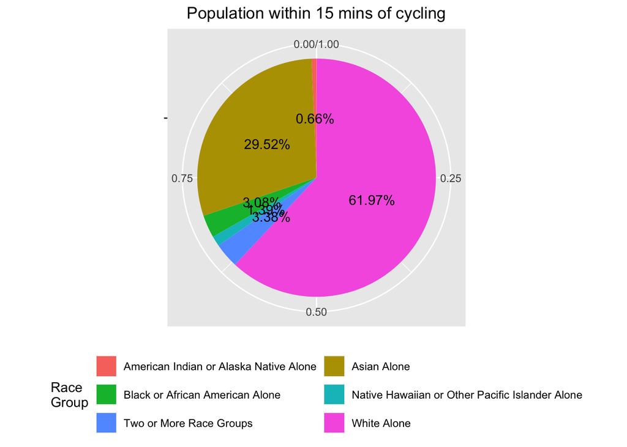

```r
race_results %>%
  ggplot(
    aes(
      x = "",
      y = ballot_perc,
      fill = race_group
    )
  ) +
  geom_bar(
    stat = "identity",
    position = position_fill()
  ) +
  geom_text(
    aes(label = paste0(round(ballot_perc*100,2),"%")),
    position = position_fill(vjust = 0.5)
  ) +
  coord_polar(theta = "y") +
  theme(
    axis.title.x = element_blank(),
    axis.title.y = element_blank(),
    legend.position = 'bottom'
  ) +
  guides(
    fill = guide_legend(nrow=3, byrow=TRUE)
  ) +
  labs(
    fill = "Race\nGroup"
  ) +
  ggtitle("Population within 15 mins of cycling") +
  theme(plot.title = element_text(hjust = 0.5))
```

Even though this analysis does not suggest any inequality in ballot-station accessibility, it is noted that the definition of accessibility could greatly affect our analysis. If the isochrones representing 10-min-walking distance were adopted, it is likely that the outcome of the equity analysis will change, e.g., some groups might be shown as the least accessible to ballot stations if we consider 10-min-walking distance to be the “accessible/bearable distance”. The choice of traveling mode “cycling”, could also be systematically disadvantaging certain groups not included in this analysis, e.g., people with physicak disabilities. Nonetheless, using 15min-cycling-isochrones in lieu of the 10min-walking-isochrones is a reasonable decision, considering that voting is not as insignificant as buying groceries and the fact that cycling is quite common in the Bay Area.

#### Acknowledgment

This study is made possible with public data from BayAreaCommunity.org and unboxproject.org. Stanford Future Bay Initiative facilitates this analysis.